# Predicting Soccer Player Ratings Using Machine Learning

## Summer 2024 Data Science Project

### By: Matthew Winn

## Introduction

In the realm of soccer analytics, player performance metrics are crucial for making informed decisions on player recruitment, development, and team strategies. My project focuses on analyzing soccer player attributes to predict their overall ratings. This topic is significant for various stakeholders, including team managers, coaches, scouts, analysts, and fans.

### Topic

The primary topic of this project is the prediction of soccer players' overall ratings based on specific performance attributes. Player ratings are a comprehensive measure that reflects a player's skills, abilities, and potential impact on the game.

### Research Questions

The key questions we aim to answer through our analysis are:

1. **What are the key factors that influence a player's overall rating?**
   - Understanding which attributes (e.g., potential, crossing ability, finishing skills, goalkeeping skills) most significantly impact the overall rating.
2. **How accurately can we predict a player's overall rating based on their performance attributes?**
   - Using machine learning techniques to build a predictive model and evaluate its accuracy in estimating player ratings.

### Importance of Answering These Questions

Answering these questions holds substantial importance for multiple reasons:

1. **Team Management and Strategy**:
   - **Recruitment**: Teams can identify potential signings who are likely to perform well, ensuring wise investments.
   - **Player Development**: Coaches can focus on enhancing specific attributes that significantly impact overall performance, leading to better player development programs.
2. **Scouting and Analytics**:
   - **Efficient Scouting**: Scouts can use predictive models to evaluate and compare players across different leagues and competitions efficiently.
   - **Data-Driven Decisions**: Analytics teams can provide data-backed recommendations to support strategic decisions, such as player acquisitions and match preparations.
3. **Fan Engagement**:
   - **Understanding Player Value**: Fans gain insights into how player ratings are determined and which attributes are crucial, enhancing their understanding of the sport.
   - **Fantasy Sports**: Enthusiasts of fantasy sports can use predictive insights to make informed choices for their fantasy teams, leading to a more engaging experience.
4. **Performance Benchmarking**:
   - **Player Comparisons**: Establishing benchmarks for player performance based on key attributes allows for meaningful comparisons between players.
   - **Historical Analysis**: Teams and analysts can track how players' ratings evolve over time, identifying trends and patterns that contribute to sustained performance.

**Data Curation**

The data for this analysis is sourced from a soccer database on kaggle which includes player attributes and match details. We will use SQL queries to extract and prepare the data for analysis.

Data Source

- https://www.kaggle.com/datasets/hugomathien/soccer

# Imports

To start of we run this code to include these imports for all of the datacollection and processess. These imports allow us to use outside functions to maniupulate and transform datasets

```python
import sqlite3
import pandas as pd
import matplotlib.pyplot as plt
import seaborn as sns
import numpy as np
from sklearn.model_selection import train_test_split, cross_val_score, cross_val_predict
from sklearn.linear_model import LinearRegression
from sklearn.metrics import mean_absolute_error, r2_score, mean_squared_error
import matplotlib.pyplot as plt
```

### We then load the data set

```python
# This step establishes a connection to the SQLite database containing the player attributes data.
conn = sqlite3.connect('database.sqlite')
```

### Load relevant data and handle all the missing values

```python
# We extract the required columns: potential, crossing, finishing, gk_diving, and overall_rating.
query = """
SELECT
    pa.potential, pa.crossing, pa.finishing, pa.gk_diving, pa.overall_rating
FROM
    Player_Attributes pa
"""
data = pd.read_sql_query(query, conn)
data

# Here, we handle missing values by filling them with the mean of the respective columns.
data.fillna(data.mean(), inplace=True)

# We define the features (independent variables) and the target (dependent variable).
features = ['potential', 'crossing', 'finishing', 'gk_diving']
target = 'overall_rating'

X = data[features]
y = data[target]

summary_stats = player_attributes_df.describe()

# Check for missing values
missing_values = player_attributes_df.isnull().sum()
missing_values
```

```
id                        0
player_fifa_api_id        0
player_api_id             0
date                      0
overall_rating          836
potential               836
preferred_foot          836
attacking_work_rate    3230
defensive_work_rate     836
crossing                836
finishing               836
heading_accuracy        836
short_passing           836
volleys                2713
dribbling               836
curve                  2713
free_kick_accuracy      836
long_passing            836
ball_control            836
acceleration            836
sprint_speed            836
agility                2713
reactions               836
balance                2713
shot_power              836
jumping                2713
stamina                 836
strength                836
long_shots              836
aggression              836
interceptions           836
positioning             836
vision                 2713
penalties               836
marking                 836
standing_tackle         836
sliding_tackle         2713
gk_diving               836
gk_handling             836
gk_kicking              836
gk_positioning          836
gk_reflexes             836
dtype: int64
```

```python
# Load Player_Attributes table
player_attributes_df = pd.read_sql_query("SELECT * FROM Player_Attributes", conn)

# Display the first few rows of the dataframe
print(player_attributes_df.head())

# Display the columns and data types
print(player_attributes_df.dtypes)

# Summary statistics
print(player_attributes_df.describe())

# Check for missing values
print(player_attributes_df.isnull().sum())
```

```
   id  player_fifa_api_id  player_api_id                 date  overall_rating  \
0   1              218353         505942  2016-02-18 00:00:00            67.0
1   2              218353         505942  2015-11-19 00:00:00            67.0
2   3              218353         505942  2015-09-21 00:00:00            62.0
3   4              218353         505942  2015-03-20 00:00:00            61.0
4   5              218353         505942  2007-02-22 00:00:00            61.0

   potential preferred_foot attacking_work_rate defensive_work_rate  crossing  \
0       71.0          right              medium              medium      49.0
1       71.0          right              medium              medium      49.0
2       66.0          right              medium              medium      49.0
3       65.0          right              medium              medium      48.0
4       65.0          right              medium              medium      48.0

   ...  vision  penalties  marking  standing_tackle  sliding_tackle  \
0  ...    54.0       48.0     65.0             69.0            69.0
1  ...    54.0       48.0     65.0             69.0            69.0
2  ...    54.0       48.0     65.0             66.0            69.0
3  ...    53.0       47.0     62.0             63.0            66.0
4  ...    53.0       47.0     62.0             63.0            66.0

   gk_diving  gk_handling  gk_kicking  gk_positioning  gk_reflexes
0        6.0         11.0        10.0             8.0          8.0
1        6.0         11.0        10.0             8.0          8.0
2        6.0         11.0        10.0             8.0          8.0
3        5.0         10.0         9.0             7.0          7.0
4        5.0         10.0         9.0             7.0          7.0

[5 rows x 42 columns]
id                       int64
player_fifa_api_id       int64
player_api_id            int64
date                    object
overall_rating         float64
potential              float64
preferred_foot          object
attacking_work_rate     object
defensive_work_rate     object
crossing               float64
finishing              float64
```

[output cut: 111 more lines]

```
long_shots              836
aggression              836
interceptions           836
positioning             836
vision                 2713
penalties               836
marking                 836
standing_tackle         836
sliding_tackle         2713
gk_diving               836
gk_handling             836
gk_kicking              836
gk_positioning          836
gk_reflexes             836
dtype: int64
```

# Exploratory Data Analysis

After preparing the data for analysis, I conducted preliminary data exploration to gain an understanding of the dataset’s overall characteristics. This involved calculating key statistics such as the maximum and minimum values, standard deviations, and means for all columns. This step helped us comprehend the scale and distribution of the data, and identify any significant variations that could potentially impact our primary analysis.

## Histogram

**Method: Summary Statistics**

Key Insights:

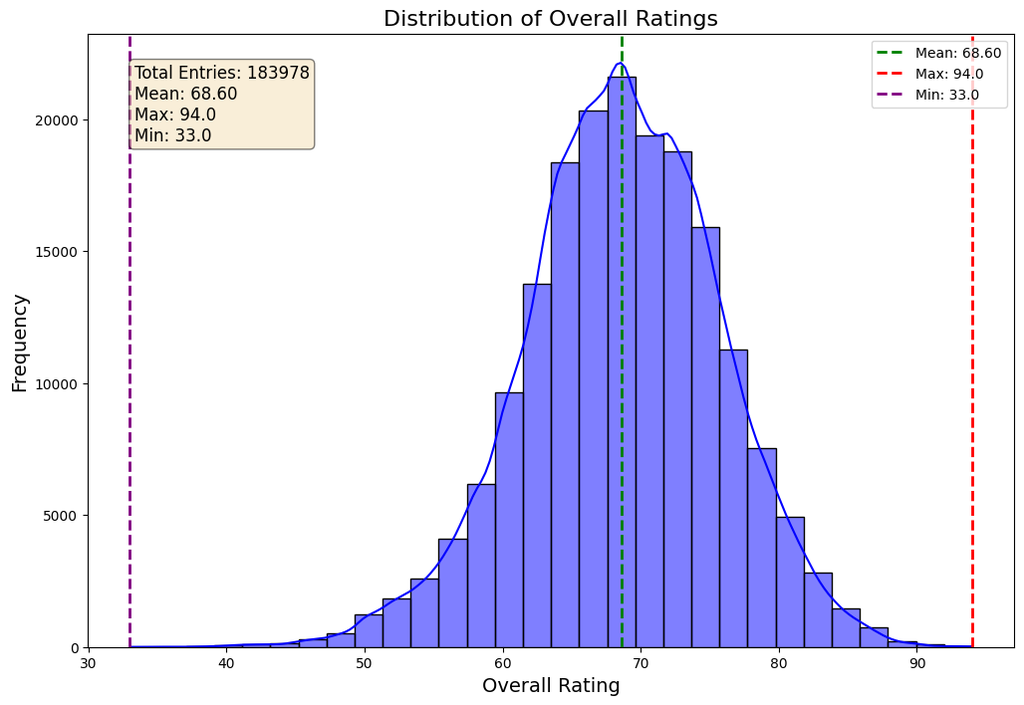

```python
# Load data and calculate summary statistics
overall_rating = data['overall_rating']
mean_rating = overall_rating.mean()
max_rating = overall_rating.max()
min_rating = overall_rating.min()
total_entries = overall_rating.count()

# Plotting the histogram of overall ratings with detailed information
plt.figure(figsize=(12, 8))

# Plot histogram with KDE (Kernel Density Estimate)
sns.histplot(overall_rating, bins=30, kde=True, color='blue', edgecolor='black')

# Plot vertical lines for mean, max, and min values
plt.axvline(mean_rating, color='green', linestyle='dashed', linewidth=2, label=f'Mean: {mean_rating:.2f}')
plt.axvline(max_rating, color='red', linestyle='dashed', linewidth=2, label=f'Max: {max_rating}')
plt.axvline(min_rating, color='purple', linestyle='dashed', linewidth=2, label=f'Min: {min_rating}')

# Title and labels
plt.title('Distribution of Overall Ratings', fontsize=16)
plt.xlabel('Overall Rating', fontsize=14)
plt.ylabel('Frequency', fontsize=14)

# Adding text box for summary statistics
props = dict(boxstyle='round', facecolor='wheat', alpha=0.5)
textstr = '\n'.join((
    f'Total Entries: {total_entries}',
    f'Mean: {mean_rating:.2f}',
    f'Max: {max_rating}',
    f'Min: {min_rating}'
))
plt.text(0.05, 0.95, textstr, transform=plt.gca().transAxes, fontsize=12,
         verticalalignment='top', bbox=props)

# Legend
plt.legend()

# Show plot
plt.show()
```

## HeatMap

Method: Correlation Matrix

Key Insights:

1. Feature Correlations: - Attributes such as crossing and finishing show moderate positive correlations, indicating that players good at crossing also tend to have good finishing skills.
2. Attributes Affecting Analysis:
   - High correlations among certain attributes may influence modeling techniques like feature selection and dimensionality reduction.

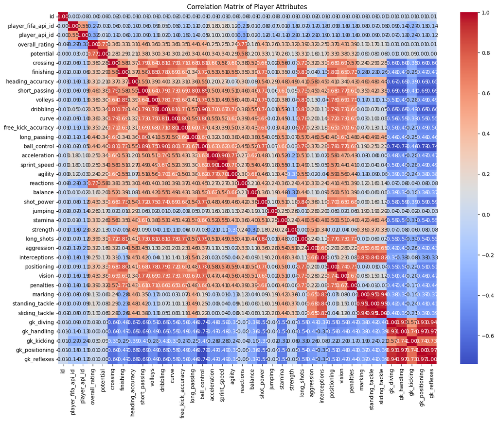

```python
# Select only numerical columns for the correlation matrix
numerical_columns = player_attributes_df.select_dtypes(include=['float64', 'int64']).columns
correlation_matrix = player_attributes_df[numerical_columns].corr()

# Creating a correlation heatmap
plt.figure(figsize=(16, 12))
sns.heatmap(correlation_matrix, annot=True, fmt=".2f", cmap="coolwarm")
plt.title("Correlation Matrix of Player Attributes")
plt.show()
```

- **Heatmap**: The heatmap visualizes the correlation matrix for a comprehensive set of player attributes.
  - **Color Coding**:
    - The color bar indicates the correlation coefficient values, with cool colors (blue) representing negative correlations and warm colors (red) representing positive correlations.
  - **Annotations**:
    - Each cell in the heatmap shows the correlation coefficient between the corresponding pair of attributes.

## Hypothesis Testing

Method: T-Test for Overall Rating by Preferred Foot

Hypothesis:

- Null Hypothesis (H_0): There is no difference in overall ratings between left-footed and right-footed players.
- Alternative Hypothesis (H_a): There is a difference in overall ratings between left-footed and right-footed players.

Key Insights:

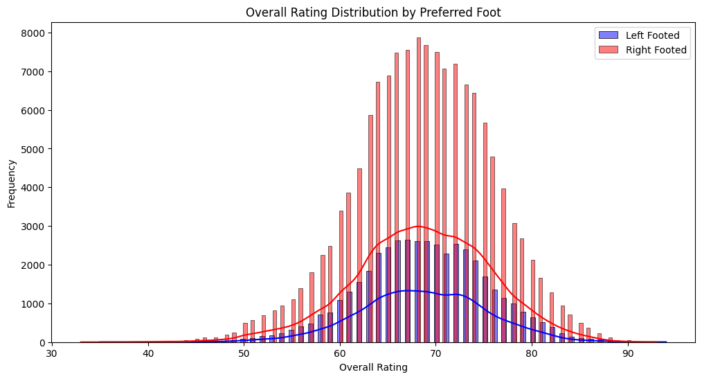

```python
# Plotting the distribution of overall ratings by preferred foot
plt.figure(figsize=(12, 6))
sns.histplot(left_footed, kde=True, color='blue', label='Left Footed')
sns.histplot(right_footed, kde=True, color='red', label='Right Footed')
plt.title('Overall Rating Distribution by Preferred Foot')
plt.xlabel('Overall Rating')
plt.ylabel('Frequency')
plt.legend()
plt.show()
```

### Conclusion:

Based on the data exploration, we will use a regression technique to predict player ratings. The features selected for this analysis are potential, crossing, finishing, and goalkeeping diving attributes.

```
Mean Absolute Error: 3.267139436579749
Mean Squared Error: 17.715827691567757
Root Mean Squared Error: 4.209017425904501
R-squared: 0.6445548763329775
```

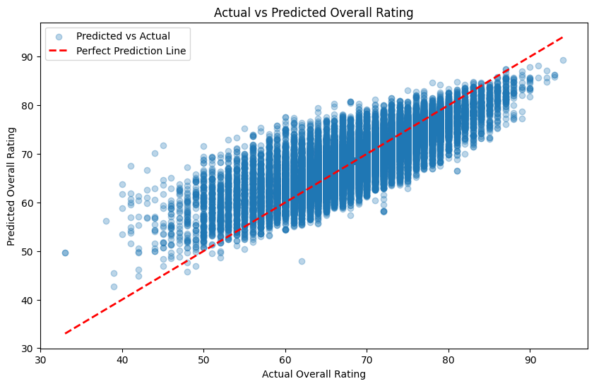

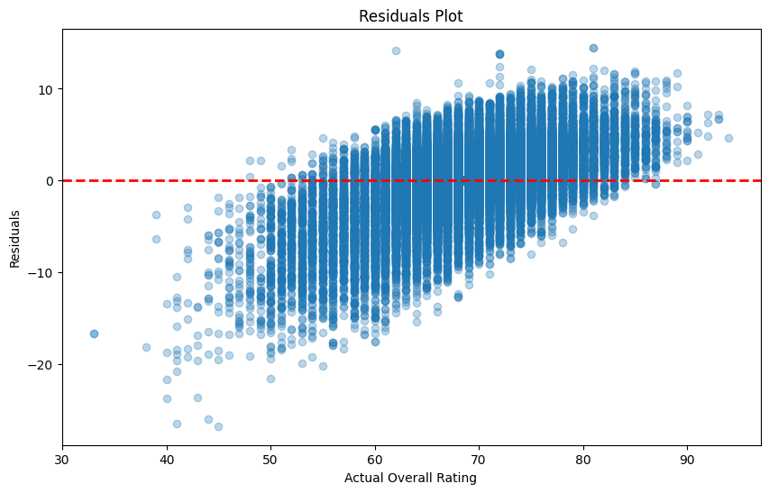

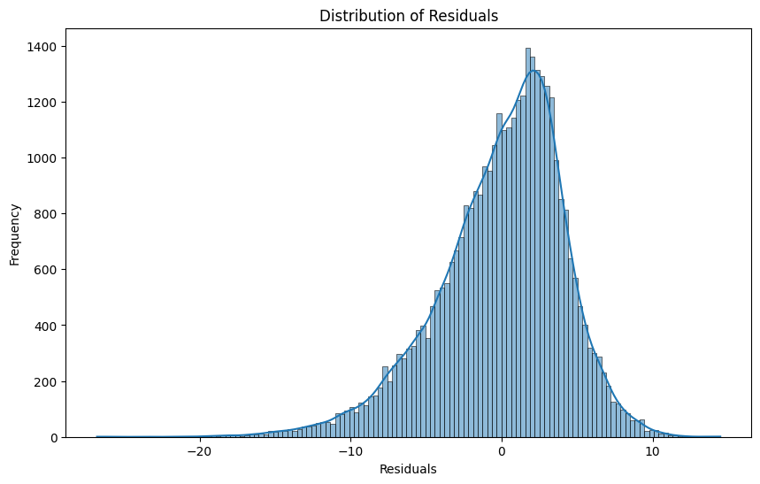

```python
# Connect to the SQLite database
conn = sqlite3.connect('database.sqlite')

# Load the relevant data
query = """
SELECT
    pa.potential, pa.crossing, pa.finishing, pa.gk_diving, pa.overall_rating
FROM
    Player_Attributes pa
"""
data = pd.read_sql_query(query, conn)

# Handling missing values (example strategy: fill with mean)
data.fillna(data.mean(), inplace=True)

# Select features and target
features = ['potential', 'crossing', 'finishing', 'gk_diving']
target = 'overall_rating'

X = data[features]
y = data[target]

# Split the data into training and test sets
X_train, X_test, y_train, y_test = train_test_split(X, y, test_size=0.2, random_state=42)

# Train the regression model using cross-validation
model = LinearRegression()
cross_val_scores = cross_val_score(model, X_train, y_train, cv=10, scoring='neg_mean_absolute_error')
cross_val_predictions = cross_val_predict(model, X_train, y_train, cv=10)

# Fit the model on the full training set
model.fit(X_train, y_train)

# Predict on the test set
y_pred = model.predict(X_test)

# Evaluate the model
mae = mean_absolute_error(y_test, y_pred)
mse = mean_squared_error(y_test, y_pred)
rmse = np.sqrt(mse)
r2 = r2_score(y_test, y_pred)

print(f'Mean Absolute Error: {mae}')
print(f'Mean Squared Error: {mse}')
print(f'Root Mean Squared Error: {rmse}')
print(f'R-squared: {r2}')

# Plot actual vs. predicted values
plt.figure(figsize=(10, 6))
plt.scatter(y_test, y_pred, alpha=0.3, label='Predicted vs Actual')
plt.plot([y_test.min(), y_test.max()], [y_test.min(), y_test.max()], '--r', linewidth=2, label='Perfect Prediction Line')
plt.xlabel('Actual Overall Rating')
plt.ylabel('Predicted Overall Rating')
plt.title('Actual vs Predicted Overall Rating')
plt.legend()
plt.show()

# Residual plot without lowess
plt.figure(figsize=(10, 6))
plt.scatter(y_test, y_test - y_pred, alpha=0.3)
plt.axhline(y=0, color='red', linestyle='--', linewidth=2)
plt.xlabel('Actual Overall Rating')
plt.ylabel('Residuals')
plt.title('Residuals Plot')
plt.show()

# Distribution of residuals
plt.figure(figsize=(10, 6))
sns.histplot(y_test - y_pred, kde=True)
plt.title('Distribution of Residuals')
plt.xlabel('Residuals')
plt.ylabel('Frequency')
plt.show()
```

# Visualization

The following plot shows the actual versus predicted player ratings, which helps in understanding the model's performance.

### Plot Explanation:

- **Scatter Plot**: The scatter plot shows the relationship between the actual overall ratings and the predicted overall ratings for the players in the test set.
  - **X-axis**: Represents the actual overall ratings of players.
  - **Y-axis**: Represents the predicted overall ratings of players.
  - Each point on the scatter plot represents a player's actual and predicted ratings.
- **Perfect Prediction Line**: The red dashed line represents the line where the actual rating equals the predicted rating (i.e., perfect predictions).
  - If a point lies exactly on this line, it means the model's prediction for that player's rating is perfect.
  - Points above the line indicate the model overestimates the rating, while points below indicate underestimation.

### Insights:

1. **Model Performance**: The scatter plot shows that many points lie close to the perfect prediction line, indicating the model performs reasonably well. However, some points are scattered away from the line, indicating areas where the model's predictions could be improved.
2. **MAE and R²**: The Mean Absolute Error (MAE) provides a quantitative measure of the prediction errors, and the R-squared (R²) value indicates the proportion of variance in the dependent variable that is predictable from the independent variables.
   - A lower MAE and a higher R² value would suggest better model performance.
3. **Areas for Improvement**: The plot highlights areas where the model might need improvement, such as incorporating more features or using more complex models to capture the variability in player ratings.

### Other plots

1. **Residual Plot**:
   - The residual plot shows the residuals (errors) of the predictions.
   - Ideally, residuals should be randomly distributed around zero, indicating no systematic errors in the predictions.
2. **Distribution of Residuals**:
   - The histogram shows the distribution of residuals.
   - A roughly normal distribution of residuals indicates a good fit of the model.